# Association Rules

Viktor Sas

2024-01-20

### Introduction

In the following report, I am analyzing the association rules between products separetely at supermarkets and at convenient stores to see how the purchase of certain products have an impact on the likelihood of purchasing other goods.

I used the following dataset during the analysis:

https://www.kaggle.com/datasets/prasad22/retail-transactions-dataset?resource=download

The dataset is well documented under the above mentioned link, therefore I am not going into too much details. However, it is worth to note that the original dataset contains data from many different kinds of stores. In order to gain a clearer picture, I decided to not analyse the whole dataset as one, instead, I created two sub datasets which contain data regarding purchases made at supermarkets and purchases made at convenience stores.

```r
supermarket <- read.transactions("supermarket.csv",sep=",")
summary(supermarket)
```

```
## transactions as itemMatrix in sparse format with
##  4978 rows (elements/itemsets/transactions) and
##  81 columns (items) and a density of 0.0362831
##
## most frequent items:
##    Toothpaste        Butter Ironing Board     Olive Oil          Tuna
##           342           207           206           205           205
##       (Other)
##         13465
##
## element (itemset/transaction) length distribution:
## sizes
##    1    2    3    4    5
## 1033 1014 1028 1030  873
##
##    Min. 1st Qu.  Median    Mean 3rd Qu.    Max.
##   1.000   2.000   3.000   2.939   4.000   5.000
##
## includes extended item information - examples:
##          labels
## 1 Air Freshener
## 2         Apple
## 3    Baby Wipes
```

```r
inspect(supermarket[1:20])
```

```
##      items
## [1]  {Bread,
##       Tissues,
##       Trash Bags,
##       Tuna}
## [2]  {Baby Wipes,
##       Banana,
##       Paper Towels,
##       Shower Gel}
## [3]  {Apple,
##       Dishware,
##       Hair Gel,
##       Plant Fertilizer,
##       Toothpaste}
## [4]  {Extension Cords,
##       Orange}
## [5]  {Cheese,
##       Insect Repellent,
##       Toilet Paper,
##       Trash Bags}
## [6]  {Ice Cream,
##       Onions,
##       Pancake Mix,
##       Pasta,
##       Vinegar}
## [7]  {Pickles}
## [8]  {Beef,
##       Broom,
##       Dustpan,
##       Shower Gel}
## [9]  {Extension Cords,
##       Laundry Detergent}
## [10] {Toothbrush,
##       Toothpaste}
## [11] {Apple}
## [12] {Banana,
##       Eggs,
##       Ketchup,
##       Olive Oil,
##       Salmon}
```

[output cut: 10 more lines]

```
##       Yogurt}
## [17] {Cheese,
##       Sponges}
## [18] {Banana,
##       Dish Soap,
##       Dishware,
##       Shower Gel,
##       Shrimp}
## [19] {Beef,
##       Light Bulbs,
##       Pancake Mix}
## [20] {Iron,
##       Shaving Cream,
##       Soda,
##       Toothpaste}
```

```r
convienience <- read.transactions("convienience.csv",sep=",")
summary(convienience)
```

```
## transactions as itemMatrix in sparse format with
##  4986 rows (elements/itemsets/transactions) and
##  81 columns (items) and a density of 0.03664087
##
## most frequent items:
## Toothpaste  Deodorant    Pickles    Sponges     Banana    (Other)
##        357        218        217        214        205      13587
##
## element (itemset/transaction) length distribution:
## sizes
##    1    2    3    4    5
##  988 1016 1048 1036  898
##
##    Min. 1st Qu.  Median    Mean 3rd Qu.    Max.
##   1.000   2.000   3.000   2.968   4.000   5.000
##
## includes extended item information - examples:
##          labels
## 1 Air Freshener
## 2         Apple
## 3    Baby Wipes
```

```r
inspect(convienience[1:20])
```

```
##      items
## [1]  {Hair Gel}
## [2]  {Jam, Ketchup, Soap}
## [3]  {Cereal, Deodorant, Ironing Board, Laundry Detergent}
## [4]  {Eggs, Syrup, Yogurt}
## [5]  {Insect Repellent, Laundry Detergent, Soda}
## [6]  {Pancake Mix}
## [7]  {Broom, Dishware, Shower Gel, Shrimp, Toothpaste}
## [8]  {Beef, Mayonnaise, Plant Fertilizer, Power Strips}
## [9]  {Cereal Bars, Garden Hose, Onions, Vacuum Cleaner}
## [10] {Canned Soup, Onions}
## [11] {Feminine Hygiene Products, Hair Gel}
## [12] {Baby Wipes, Cereal, Shower Gel, Soda, Tuna}
## [13] {Hair Gel, Insect Repellent, Orange, Shower Gel}
## [14] {Razors, Water}
## [15] {Diapers, Orange, Vinegar}
## [16] {Onions, Sponges}
## [17] {Bread, Deodorant, Tuna}
## [18] {Canned Soup, Tea, Trash Bags}
## [19] {Dishware, Dustpan, Hair Gel, Potatoes, Razors}
## [20] {Bread, Mop, Plant Fertilizer, Salmon, Spinach}
```

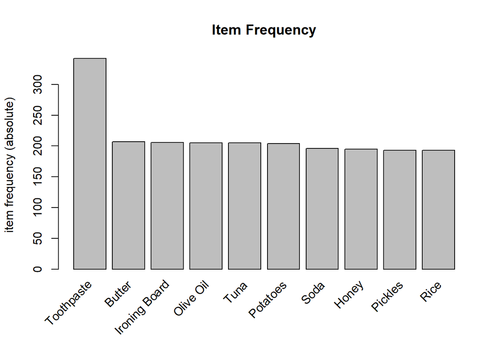

```r
itemFrequencyPlot(supermarket,topN=10, type="absolute", main="Item Frequency")
```

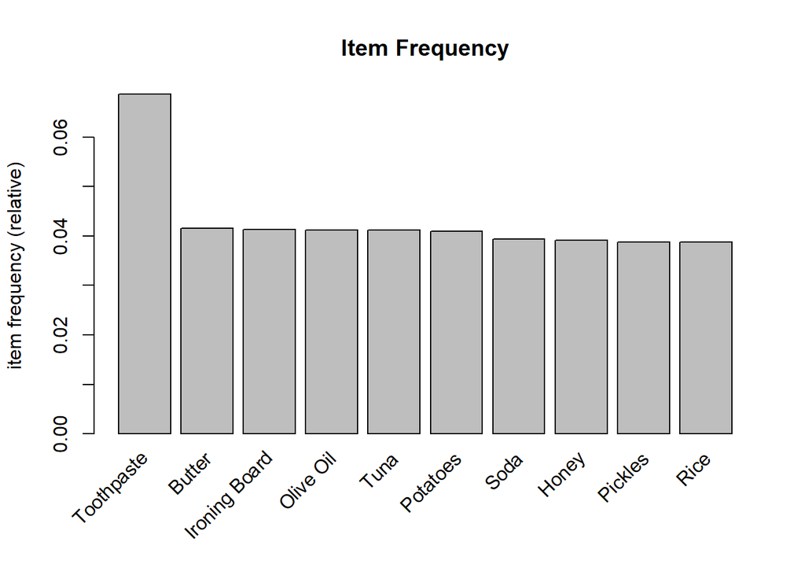

```r
itemFrequencyPlot(supermarket, topN=10, type="relative", main="Item Frequency")
```

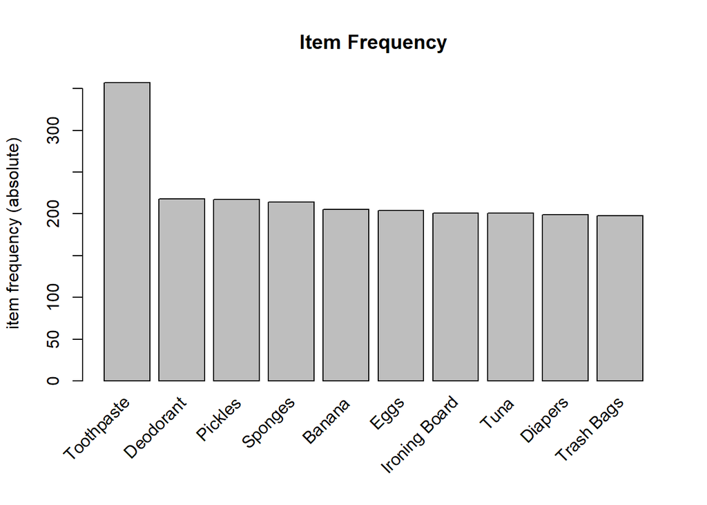

```r
itemFrequencyPlot(convienience,topN=10, type="absolute", main="Item Frequency")
```

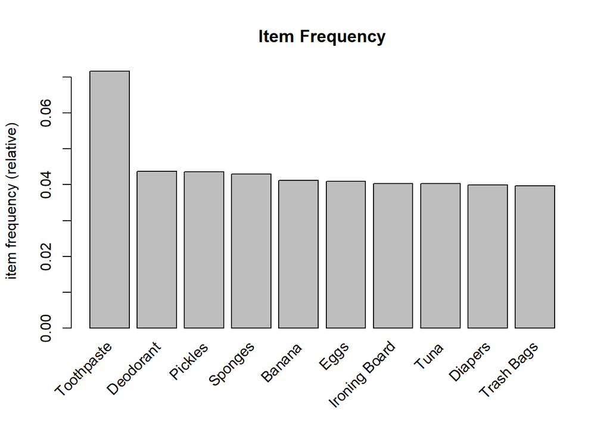

```r
itemFrequencyPlot(convienience, topN=10, type="relative", main="Item Frequency")
```

Since we have around 5000 supermarket and 5000 convienience store transactions and the relative occurance of our products are low, under 0.08, I chose a low support and confidence level to find the association rules.

```r
rules_sup <- apriori(supermarket, parameter = list(supp=0.001, conf=0.07, minlen=2))
```

```
## Apriori
##
## Parameter specification:
##  confidence minval smax arem  aval originalSupport maxtime support minlen
##        0.07    0.1    1 none FALSE            TRUE       5   0.001      2
##  maxlen target  ext
##      10  rules TRUE
##
## Algorithmic control:
##  filter tree heap memopt load sort verbose
##     0.1 TRUE TRUE  FALSE TRUE    2    TRUE
##
## Absolute minimum support count: 4
##
## set item appearances ...[0 item(s)] done [0.00s].
## set transactions ...[81 item(s), 4978 transaction(s)] done [0.00s].
## sorting and recoding items ... [81 item(s)] done [0.00s].
## creating transaction tree ... done [0.00s].
## checking subsets of size 1 2 3 done [0.00s].
## writing ... [70 rule(s)] done [0.00s].
## creating S4 object  ... done [0.00s].
```

```r
rules_con <- apriori(convienience, parameter = list(supp=0.001, conf=0.07, minlen=2))
```

```
## Apriori
##
## Parameter specification:
##  confidence minval smax arem  aval originalSupport maxtime support minlen
##        0.07    0.1    1 none FALSE            TRUE       5   0.001      2
##  maxlen target  ext
##      10  rules TRUE
##
## Algorithmic control:
##  filter tree heap memopt load sort verbose
##     0.1 TRUE TRUE  FALSE TRUE    2    TRUE
##
## Absolute minimum support count: 4
##
## set item appearances ...[0 item(s)] done [0.00s].
## set transactions ...[81 item(s), 4986 transaction(s)] done [0.00s].
## sorting and recoding items ... [81 item(s)] done [0.00s].
## creating transaction tree ... done [0.00s].
## checking subsets of size 1 2 3 done [0.00s].
## writing ... [68 rule(s)] done [0.00s].
## creating S4 object  ... done [0.00s].
```

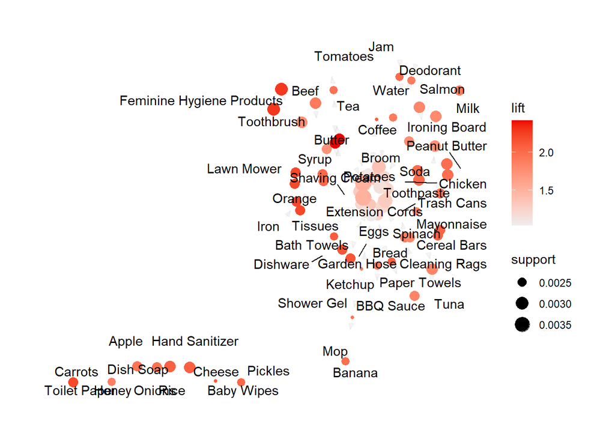

```r
plot(rules_sup, method="graph")
```

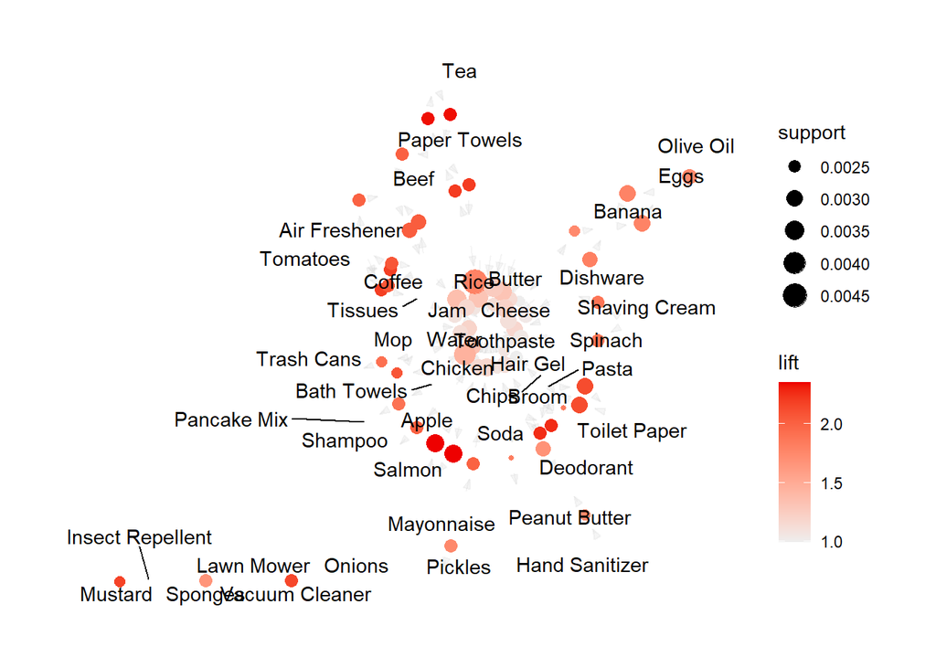

```r
plot(rules_con, method="graph")
```

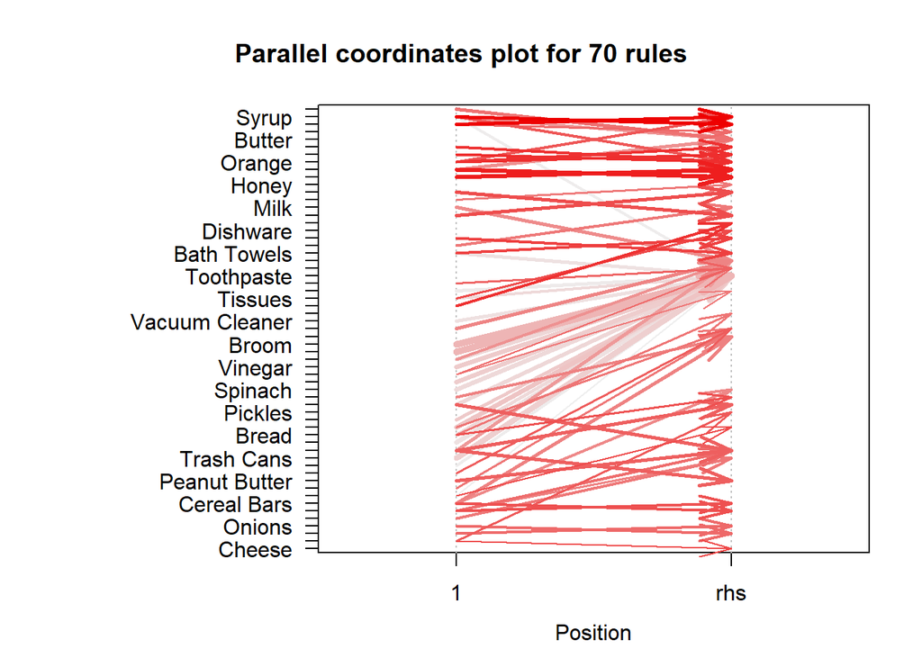

```r
plot(rules_sup, method = "paracoord")
```

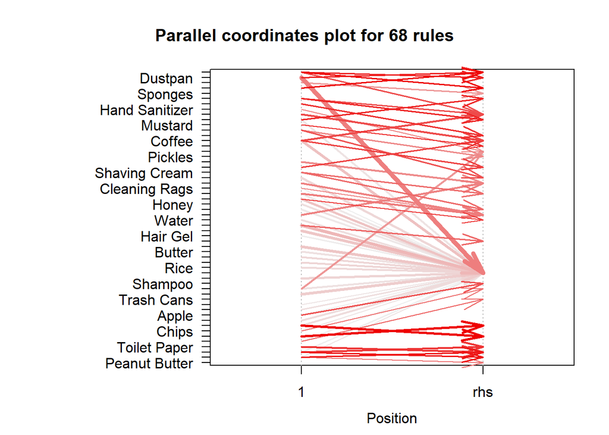

```r
plot(rules_con, method = "paracoord")
```

```
## To reduce overplotting, jitter is added! Use jitter = 0 to prevent jitter.
```

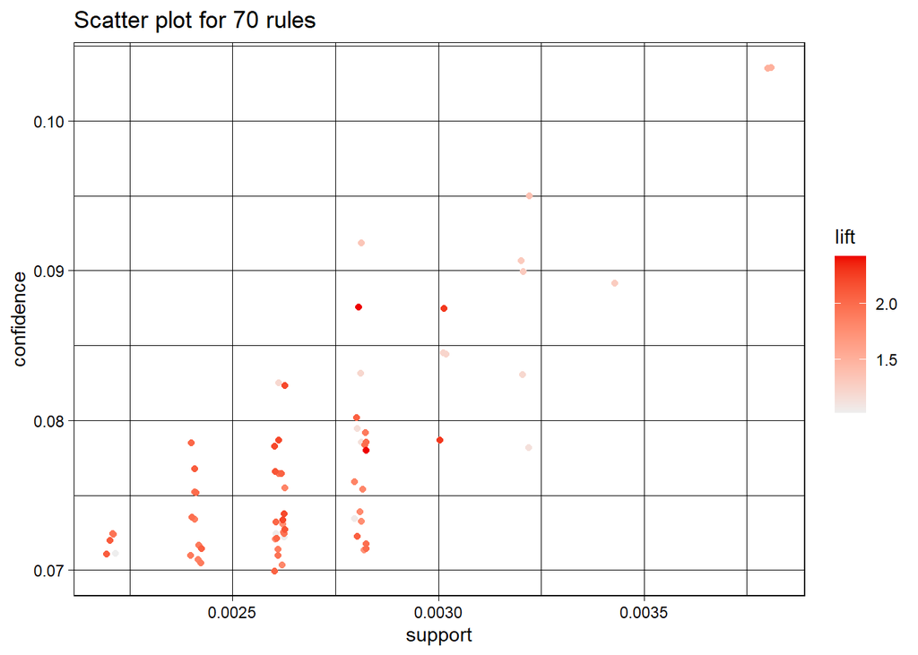

```r
plot(rules_sup)
```

```
## To reduce overplotting, jitter is added! Use jitter = 0 to prevent jitter.
```

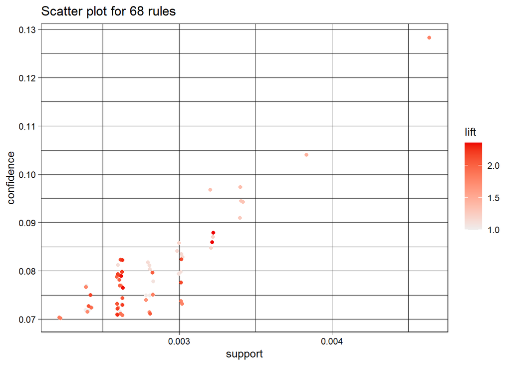

```r
plot(rules_con)
```

```r
inspect(sort(rules_sup, by = "support")[1:10])
```

```
##      lhs                            rhs                         support
## [1]  {Extension Cords}           => {Toothpaste}                0.003816794
## [2]  {Broom}                     => {Toothpaste}                0.003816794
## [3]  {Trash Cans}                => {Toothpaste}                0.003415026
## [4]  {Coffee}                    => {Toothpaste}                0.003214142
## [5]  {Shaving Cream}             => {Toothpaste}                0.003214142
## [6]  {Vinegar}                   => {Toothpaste}                0.003214142
## [7]  {Spinach}                   => {Toothpaste}                0.003214142
## [8]  {Potatoes}                  => {Toothpaste}                0.003214142
## [9]  {Feminine Hygiene Products} => {Toothbrush}                0.003013258
## [10] {Toothbrush}                => {Feminine Hygiene Products} 0.003013258
##      confidence coverage   lift     count
## [1]  0.10326087 0.03696264 1.503019 19
## [2]  0.10326087 0.03696264 1.503019 19
## [3]  0.08900524 0.03836882 1.295521 17
## [4]  0.09467456 0.03394938 1.378041 16
## [5]  0.08988764 0.03575733 1.308365 16
## [6]  0.09039548 0.03555645 1.315756 16
## [7]  0.08290155 0.03877059 1.206678 16
## [8]  0.07843137 0.04098031 1.141612 16
## [9]  0.08771930 0.03435115 2.286213 15
## [10] 0.07853403 0.03836882 2.286213 15
```

As the earlier graph already suggested, toothpaste seems to be the most bought item in the supermarket. It appears most often with Extension Cords, Broom and Trash Cans in the same transactions, 19 transactions in the first 2 cases and 17 in the 3rd.

```r
inspect(sort(rules_con, by = "support")[1:10])
```

```
##      lhs                 rhs              support     confidence coverage
## [1]  {Dustpan}        => {Toothpaste}     0.004612916 0.12849162 0.03590052
## [2]  {Bath Towels}    => {Toothpaste}     0.003810670 0.10382514 0.03670277
## [3]  {Carrots}        => {Toothpaste}     0.003409547 0.09444444 0.03610108
## [4]  {Coffee}         => {Toothpaste}     0.003409547 0.09714286 0.03509828
## [5]  {Garden Hose}    => {Toothpaste}     0.003409547 0.09444444 0.03610108
## [6]  {Razors}         => {Toothpaste}     0.003409547 0.09042553 0.03770558
## [7]  {Chicken}        => {Toothpaste}     0.003208985 0.09638554 0.03329322
## [8]  {Cleaning Spray} => {Salmon}         0.003208985 0.08791209 0.03650221
## [9]  {Salmon}         => {Cleaning Spray} 0.003208985 0.08602151 0.03730445
## [10] {Yogurt}         => {Toothpaste}     0.003208985 0.08648649 0.03710389
##      lift     count
## [1]  1.794564 23
## [2]  1.450062 19
## [3]  1.319048 17
## [4]  1.356735 17
## [5]  1.319048 17
## [6]  1.262918 17
## [7]  1.346158 16
## [8]  2.356611 16
## [9]  2.356611 16
## [10] 1.207904 16
```

We can observe a similar situation at the convinience store, Toothpaste is the most bought item, however it appears most often with Dustpan (23 transactions), Bath Towels(19 transaction) and Carrots (17 transactions).

```r
inspect(sort(rules_sup, by = "lift")[1:10])
```

```
##      lhs                            rhs                         support
## [1]  {Syrup}                     => {Tea}                       0.002812374
## [2]  {Tea}                       => {Syrup}                     0.002812374
## [3]  {Feminine Hygiene Products} => {Toothbrush}                0.003013258
## [4]  {Toothbrush}                => {Feminine Hygiene Products} 0.003013258
## [5]  {Orange}                    => {Iron}                      0.002611491
## [6]  {Iron}                      => {Orange}                    0.002611491
## [7]  {Orange}                    => {Lawn Mower}                0.002611491
## [8]  {Lawn Mower}                => {Orange}                    0.002611491
## [9]  {Carrots}                   => {Toilet Paper}              0.002611491
## [10] {Ketchup}                   => {Bath Towels}               0.002611491
##      confidence coverage   lift     count
## [1]  0.07777778 0.03615910 2.419861 14
## [2]  0.08750000 0.03214142 2.419861 14
## [3]  0.08771930 0.03435115 2.286213 15
## [4]  0.07853403 0.03836882 2.286213 15
## [5]  0.07344633 0.03555645 2.215853 13
## [6]  0.07878788 0.03314584 2.215853 13
## [7]  0.07344633 0.03555645 2.202505 13
## [8]  0.07831325 0.03334673 2.202505 13
## [9]  0.08227848 0.03173965 2.202055 13
## [10] 0.07647059 0.03415026 2.138599 13
```

```r
inspect(sort(rules_con, by = "lift")[1:10])
```

```
##      lhs                            rhs                         support
## [1]  {Cleaning Spray}            => {Salmon}                    0.003208985
## [2]  {Salmon}                    => {Cleaning Spray}            0.003208985
## [3]  {Paper Towels}              => {Tea}                       0.002607300
## [4]  {Tea}                       => {Paper Towels}              0.002607300
## [5]  {Feminine Hygiene Products} => {Pasta}                     0.002607300
## [6]  {Pasta}                     => {Feminine Hygiene Products} 0.002607300
## [7]  {Paper Towels}              => {Dustpan}                   0.002607300
## [8]  {Dustpan}                   => {Paper Towels}              0.002607300
## [9]  {Tissues}                   => {Air Freshener}             0.002607300
## [10] {Air Freshener}             => {Tissues}                   0.002607300
##      confidence coverage   lift     count
## [1]  0.08791209 0.03650221 2.356611 16
## [2]  0.08602151 0.03730445 2.356611 16
## [3]  0.07926829 0.03289210 2.338649 13
## [4]  0.07692308 0.03389491 2.338649 13
## [5]  0.08280255 0.03148817 2.268426 13
## [6]  0.07142857 0.03650221 2.268426 13
## [7]  0.07926829 0.03289210 2.207998 13
## [8]  0.07262570 0.03590052 2.207998 13
## [9]  0.07262570 0.03590052 2.194617 13
## [10] 0.07878788 0.03309266 2.194617 13
```

In case of the convenience store, we find a strong lift between Cleaning Spray + Salmon, Paper Towels + Tea, Hygiene Products + Pasta, in all cases the lift is over 2.0 which suggests a strong positive association between the products.

```r
inspect(sort(rules_sup, by = "confidence")[1:10])
```

```
##      lhs                            rhs          support     confidence
## [1]  {Extension Cords}           => {Toothpaste} 0.003816794 0.10326087
## [2]  {Broom}                     => {Toothpaste} 0.003816794 0.10326087
## [3]  {Coffee}                    => {Toothpaste} 0.003214142 0.09467456
## [4]  {Eggs}                      => {Toothpaste} 0.002812374 0.09210526
## [5]  {Vinegar}                   => {Toothpaste} 0.003214142 0.09039548
## [6]  {Shaving Cream}             => {Toothpaste} 0.003214142 0.08988764
## [7]  {Trash Cans}                => {Toothpaste} 0.003415026 0.08900524
## [8]  {Feminine Hygiene Products} => {Toothbrush} 0.003013258 0.08771930
## [9]  {Tea}                       => {Syrup}      0.002812374 0.08750000
## [10] {Chicken}                   => {Toothpaste} 0.003013258 0.08426966
##      coverage   lift     count
## [1]  0.03696264 1.503019 19
## [2]  0.03696264 1.503019 19
## [3]  0.03394938 1.378041 16
## [4]  0.03053435 1.340643 14
## [5]  0.03555645 1.315756 16
## [6]  0.03575733 1.308365 16
## [7]  0.03836882 1.295521 17
## [8]  0.03435115 2.286213 15
## [9]  0.03214142 2.419861 14
## [10] 0.03575733 1.226592 15
```

The Supermarket Rules indicate that in case Extension Cords or Broom is placed in the basked, there is over 10% probability that the customer will purchase Toothpaste as well.

```r
inspect(sort(rules_con, by = "confidence")[1:10])
```

```
##      lhs                 rhs              support     confidence coverage
## [1]  {Dustpan}        => {Toothpaste}     0.004612916 0.12849162 0.03590052
## [2]  {Bath Towels}    => {Toothpaste}     0.003810670 0.10382514 0.03670277
## [3]  {Coffee}         => {Toothpaste}     0.003409547 0.09714286 0.03509828
## [4]  {Chicken}        => {Toothpaste}     0.003208985 0.09638554 0.03329322
## [5]  {Carrots}        => {Toothpaste}     0.003409547 0.09444444 0.03610108
## [6]  {Garden Hose}    => {Toothpaste}     0.003409547 0.09444444 0.03610108
## [7]  {Razors}         => {Toothpaste}     0.003409547 0.09042553 0.03770558
## [8]  {Cleaning Spray} => {Salmon}         0.003208985 0.08791209 0.03650221
## [9]  {Yogurt}         => {Toothpaste}     0.003208985 0.08648649 0.03710389
## [10] {Salmon}         => {Cleaning Spray} 0.003208985 0.08602151 0.03730445
##      lift     count
## [1]  1.794564 23
## [2]  1.450062 19
## [3]  1.356735 17
## [4]  1.346158 16
## [5]  1.319048 17
## [6]  1.319048 17
## [7]  1.262918 17
## [8]  2.356611 16
## [9]  1.207904 16
## [10] 2.356611 16
```

The Convenience Store Rules indicate that in a Dustpan or Bath Towels are placed in the basked, there is over 12% and 10% probability that the customer will purchase Toothpaste as well.

### Finding Rules based on certain products:

```r
rule_pancake_sup <- apriori(data=supermarket, parameter=list(supp=0.0003, conf=0.001, minlen=2), appearance=list(default="rhs", lhs="Pancake Mix"), control=list(verbose=F))
pancake_confidence<-sort(rule_pancake_sup, by="confidence", decreasing=TRUE)
inspect((pancake_confidence[1:15]), linebreak = FALSE)
```

```
##      lhs              rhs                support     confidence coverage
## [1]  {Pancake Mix} => {Chips}            0.002008839 0.06134969 0.03274407
## [2]  {Pancake Mix} => {Light Bulbs}      0.002008839 0.06134969 0.03274407
## [3]  {Pancake Mix} => {Onions}           0.002008839 0.06134969 0.03274407
## [4]  {Pancake Mix} => {Shampoo}          0.001807955 0.05521472 0.03274407
## [5]  {Pancake Mix} => {Sponges}          0.001807955 0.05521472 0.03274407
## [6]  {Pancake Mix} => {Cereal Bars}      0.001807955 0.05521472 0.03274407
## [7]  {Pancake Mix} => {Shrimp}           0.001807955 0.05521472 0.03274407
## [8]  {Pancake Mix} => {Pickles}          0.001807955 0.05521472 0.03274407
## [9]  {Pancake Mix} => {Tuna}             0.001807955 0.05521472 0.03274407
## [10] {Pancake Mix} => {Power Strips}     0.001607071 0.04907975 0.03274407
## [11] {Pancake Mix} => {Dish Soap}        0.001607071 0.04907975 0.03274407
## [12] {Pancake Mix} => {Shaving Cream}    0.001607071 0.04907975 0.03274407
## [13] {Pancake Mix} => {Diapers}          0.001607071 0.04907975 0.03274407
## [14] {Pancake Mix} => {Insect Repellent} 0.001607071 0.04907975 0.03274407
```

[output cut: 17 more lines]

According to the association rules based on Pancake Mix, in case someone purchases Pancake Mix, there is a good chance they would also purchase Chips, Light Buls, Onions etc.

```r
rule_pancake_sup <- apriori(data=supermarket, parameter=list(supp=0.0003, conf=0.001, minlen=2), appearance=list(default="rhs", lhs="Pancake Mix"), control=list(verbose=F))
pancake_confidence<-sort(rule_pancake_sup, by="confidence", decreasing=TRUE)
inspect((pancake_confidence[1:15]), linebreak = FALSE)
```

```
##      lhs              rhs                support     confidence coverage
## [1]  {Pancake Mix} => {Chips}            0.002008839 0.06134969 0.03274407
## [2]  {Pancake Mix} => {Light Bulbs}      0.002008839 0.06134969 0.03274407
## [3]  {Pancake Mix} => {Onions}           0.002008839 0.06134969 0.03274407
## [4]  {Pancake Mix} => {Shampoo}          0.001807955 0.05521472 0.03274407
## [5]  {Pancake Mix} => {Sponges}          0.001807955 0.05521472 0.03274407
## [6]  {Pancake Mix} => {Cereal Bars}      0.001807955 0.05521472 0.03274407
## [7]  {Pancake Mix} => {Shrimp}           0.001807955 0.05521472 0.03274407
## [8]  {Pancake Mix} => {Pickles}          0.001807955 0.05521472 0.03274407
## [9]  {Pancake Mix} => {Tuna}             0.001807955 0.05521472 0.03274407
## [10] {Pancake Mix} => {Power Strips}     0.001607071 0.04907975 0.03274407
## [11] {Pancake Mix} => {Dish Soap}        0.001607071 0.04907975 0.03274407
## [12] {Pancake Mix} => {Shaving Cream}    0.001607071 0.04907975 0.03274407
## [13] {Pancake Mix} => {Diapers}          0.001607071 0.04907975 0.03274407
## [14] {Pancake Mix} => {Insect Repellent} 0.001607071 0.04907975 0.03274407
```

[output cut: 17 more lines]

```r
rule_shampoo_con <- apriori(data=convienience, parameter=list(supp=0.0003, conf=0.001, minlen=2), appearance=list(default="rhs", lhs="Shampoo"), control=list(verbose=F))
shampoo_confidence<-sort(rule_shampoo_con, by="confidence", decreasing=TRUE)
inspect((shampoo_confidence[1:15]), linebreak = FALSE)
```

```
##      lhs          rhs             support     confidence coverage   lift
## [1]  {Shampoo} => {Apple}         0.002607300 0.06735751 0.03870838 2.0110453
## [2]  {Shampoo} => {Toothpaste}    0.002406739 0.06217617 0.03870838 0.8683764
## [3]  {Shampoo} => {Jam}           0.002206177 0.05699482 0.03870838 1.6238638
## [4]  {Shampoo} => {Shaving Cream} 0.002206177 0.05699482 0.03870838 1.5528752
## [5]  {Shampoo} => {Toothbrush}    0.002206177 0.05699482 0.03870838 1.5278288
## [6]  {Shampoo} => {Trash Bags}    0.002206177 0.05699482 0.03870838 1.4352332
## [7]  {Shampoo} => {Chips}         0.002005616 0.05181347 0.03870838 1.6454902
## [8]  {Shampoo} => {Milk}          0.002005616 0.05181347 0.03870838 1.4432512
## [9]  {Shampoo} => {Dishware}      0.002005616 0.05181347 0.03870838 1.3741594
## [10] {Shampoo} => {Peanut Butter} 0.002005616 0.05181347 0.03870838 1.3596946
## [11] {Shampoo} => {Pickles}       0.002005616 0.05181347 0.03870838 1.1905160
## [12] {Shampoo} => {Dish Soap}     0.001805054 0.04663212 0.03870838 1.3286158
## [13] {Shampoo} => {Paper Towels}  0.001604493 0.04145078 0.03870838 1.2602047
## [14] {Shampoo} => {Garden Hose}   0.001604493 0.04145078 0.03870838 1.1481865
```

[output cut: 17 more lines]

### Summary:

Thanks to different methods of association rules we can have an insight into the choices of customers and their purchasing “path”, we can also discover which products likely “trigger” the purchase of other products. Based on these insights supermarkets can make informed decisions for example about the organisation of products in their stores.